# Hierarchical modeling

### Prof. Manuel A. Rivas (rivaslab.stanford.edu)

#### Topics in Biomedical Data Science : Large-scale inference

#### Lecture number 9

#### 5/2/2017

[figure not shown]

# Motivating examples for today

- Dependencies on effects
- Tissues, cells, genes

## Bernoulli Likelihood with hierarchical prior

1. A single coin from a single mint
2. Multiple coins from a single mint
3. Multiple coins from multiple mints

Goal: Assume you have two coins. Estimate each parameter $\theta_1$ and $\theta_2$ and estimate each bias in each coin.

Let's explore situations in which there are two or more parameters that do have meaningful dependencies.

Example: The bias of a coin depends on characteristics of the factory in which it is minted

Prior beliefs about parameters values of the mint

Dependence of the coin's bias on the minting parameter

Parameters that directly affect the data: **parameters**

Parameters that affect data indirectly by affecting beliefs about other parameters: **hyperparameters**

\begin{align}P\left(y|\theta\right) &=& \mathrm{Ber}\left(y|\theta\right) \\ &=& \theta^{y}\left(1 - \theta\right)^{1-y} \end{align}

$y = 1$ for head  
$y = 0$ for tail

### Prior distribution

\begin{align} p\left(\theta\right) \sim \textrm{Beta}\left(a, b\right) \end{align}

To make parameters of beta more intuitive, we express them in terms of the corresponding mean $\mu$ and sample size $K$.

If mean is $w$ and confidence is reflected by prior sample size $K$

\begin{align} a &=& w (K-2) + 1 \\ b &=&\left(1-w\right)(K - 2) + 1 \end{align}

\begin{align} p\left(\theta| \mu\right) = \textrm{Beta}\left(\theta | w (K-2) + 1 , \left(1-w\right)(K - 2) + 1\right) \end{align}

The magnitude of $K$ is an expression of our prior certainty regarding the dependence of the bias on $w$.

When $K$ is large, the distribution of $\theta$ is very narrowly loaded over $\mu$.

When $K$ is small, the distribution of $\theta$ is very widely dispersed around $w$.

Thus, as $K$ gets large, we are more and more certain about the form of the dependency of $\theta$ on $w$.

![coinflip](https://www.dropbox.com/s/0l9ta7lg8nc9cna/coinflip1.001.png?dl=1 "Source: Kruschke Doing Bayesian Data Analysis")

### Expansion of the scenario into the realm of hierarchical models

Instead of specifying a single particular value for $w$

We think of $w$ as taking on many possible values (from 0 to 1), and we specify a probability distribution over those values.

This distribution can be thought of as describing the uncertainty in our beliefs about the construction of the mint that manufactured the coin.

### Expansion of the scenario into the realm of hierarchical models

When $w$ is large, the mint tends to produce coins with large biases, and when $w$ is small, the mint tends to produce coins with small biases.

Our prior distribution over $w$ expresses what we believe about how mints are constructed. We suppose that the distribution on $w$ is again a beta distribution, $p\left(w\right) = \textrm{Beta}\left(w|A_{w}, B_{w}\right)$ where $A_{w}$ and $B_{w}$ are constants. In this case, we believe that $w$ is typically near $A_{w}/(A_{w}+B_{w})$.

The hyperparameter $w$ expresses the bias of the mint that created the coin, and $w$ depends on a beta distribution with parameters $A_{w}$ and $B_{w}$, which are set by prior beliefs

This form of model is referred to as a **hierarchical model** because of the layers of dependencies.

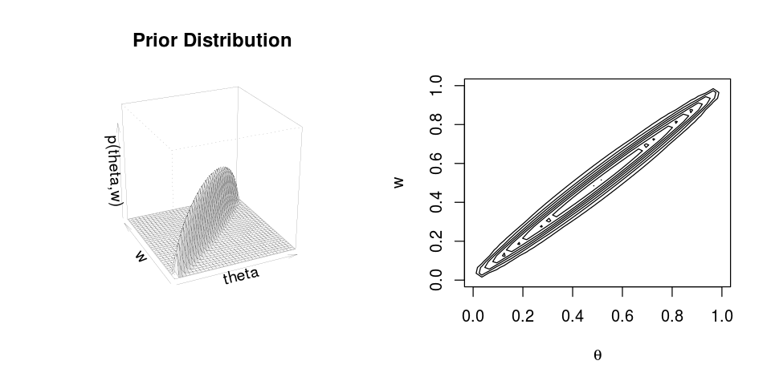

```r
par(mfrow=c(1,2))
options(repr.plot.width=8, repr.plot.height=4)
persp(thetas[step.thetas] , mus[step.mus] , priors[step.thetas,step.mus],
      xlab="theta" , ylab="w" , main="Prior Distribution" , cex=perspcex ,
      lwd=0.1  , xlim=c(0,1) , ylim=c(0,1) , zlim=c(0,2*zmax),
      zlab="p(theta,w)" , theta=rotate , phi=tilt , d=parallelness ,
      shade=shadeval)
contour(thetas[step.thetas] , mus[step.mus] , priors[step.thetas,step.mus],
        main=bquote(" ") , levels=signif(seq(0,zmax,length=ncontours),3) ,
        drawlabels=FALSE , xlab=bquote(theta) , ylab=bquote(w) )
```

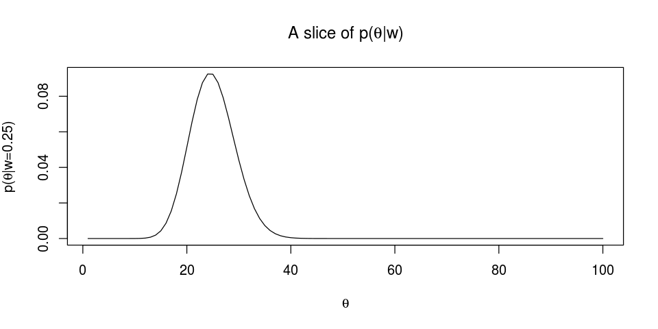

```r
par(mfrow=c(1,1))
options(repr.plot.width=8, repr.plot.height=4)
mu <- 0.25
col <- 100*round(mu*100/dim.grid,2) # find right column
plot(priors[,col]/sum(priors[,col]),
     type="l",xlab=bquote(theta),
     ylab=bquote(paste("p(",theta,"|",w,"=",.(mu),")")),
     main=bquote(paste("A slice of p(",theta,"|",w,")")))
```

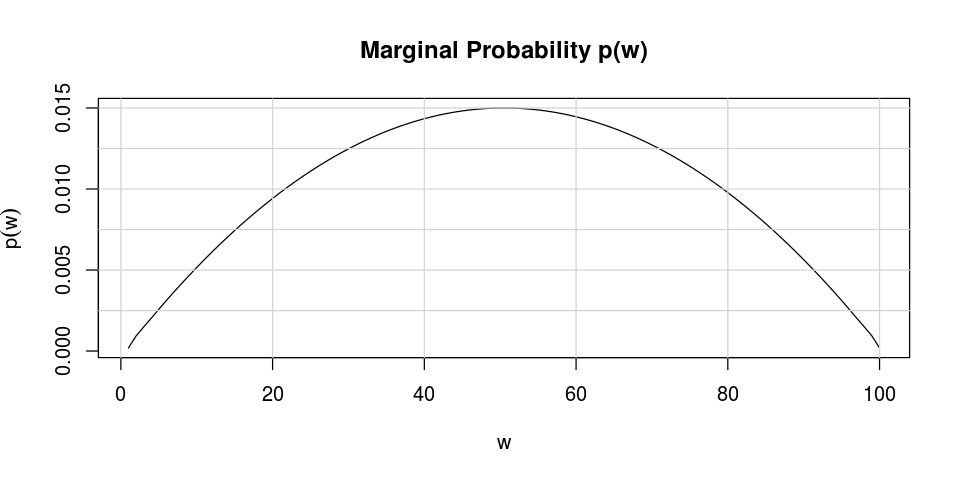

```r
options(repr.plot.width=8, repr.plot.height=4)
plot(marginal.mu, xlab=bquote(w), ylab=bquote(p(w)),type="l")
title("Marginal Probability p(w)")
abline(v=seq(0,100,20),h=seq(.0025,.015,.0025),col="lightgray")
```

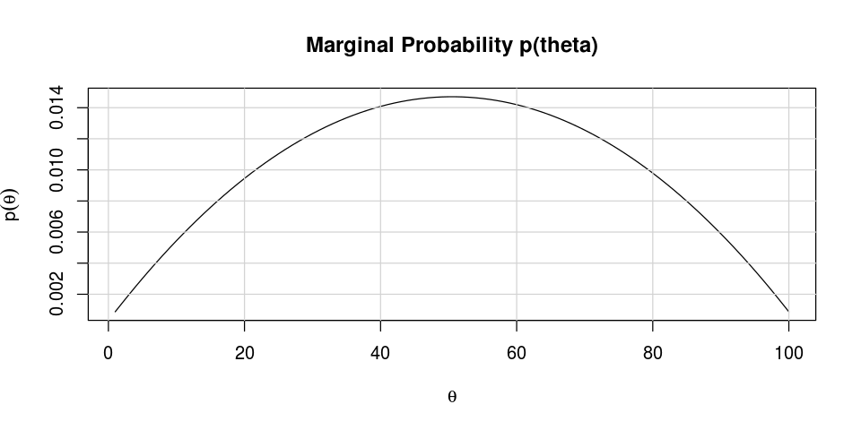

```r
options(repr.plot.width=8, repr.plot.height=4)
plot(marginal.theta, xlab=bquote(theta), ylab=bquote(p(theta)),type="l")
title("Marginal Probability p(theta)")
abline(v=seq(0,100,20),h=seq(.002,.016,.002),col="lightgray")
```

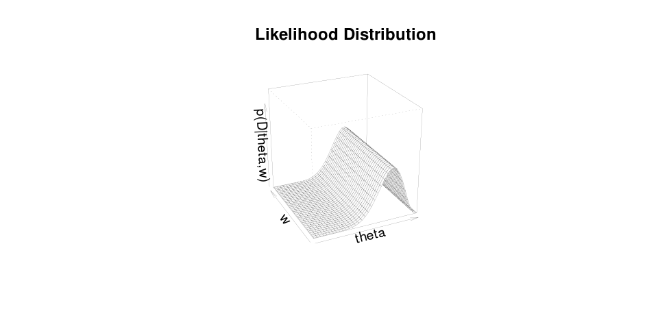

```r
options(repr.plot.width=8, repr.plot.height=4)
persp(thetas[step.thetas] , mus[step.mus] , likelihoods[step.thetas,step.mus],
      xlab="theta" , ylab="w" , main="Likelihood Distribution", cex=perspcex,
      lwd=0.1  , xlim=c(0,1) , ylim=c(0,1) , zlim=c(0,2*zmax),
      zlab="p(D|theta,w)" , theta=rotate , phi=tilt , d=parallelness ,
      shade=shadeval)
```

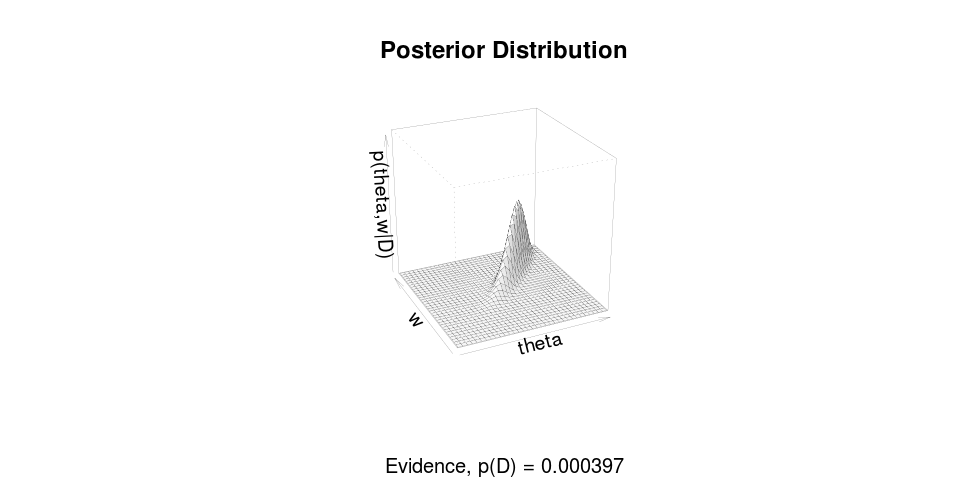

```r
options(repr.plot.width=8, repr.plot.height=4)
persp(thetas[step.thetas] , mus[step.mus] , posteriors[step.thetas,step.mus],
      xlab="theta" , ylab="w" , main="Posterior Distribution",
      sub=paste0("Evidence, p(D) = ", signif(evidence,3)),
      cex=perspcex, lwd=0.1  , xlim=c(0,1) , ylim=c(0,1) , zlim=c(0,2*zmax),
      zlab="p(theta,w|D)" , theta=rotate , phi=tilt , d=parallelness ,
      shade=shadeval)
```

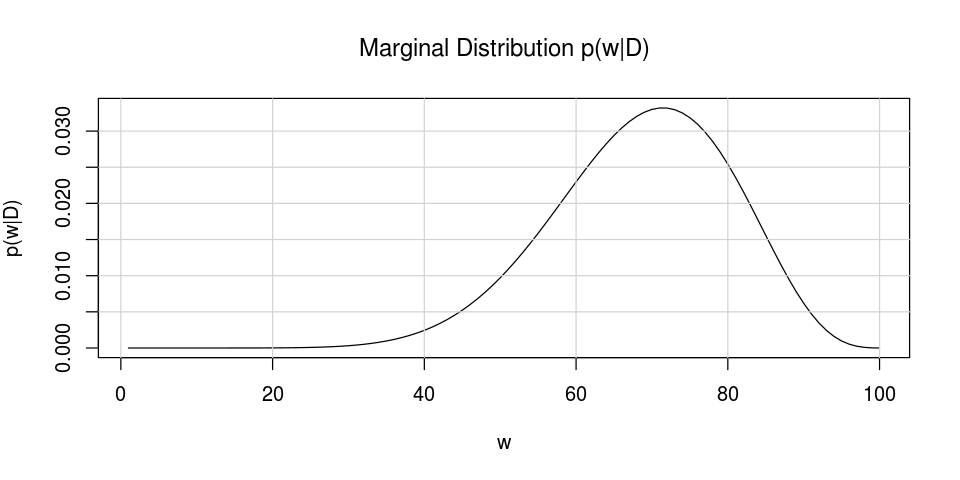

```r
options(repr.plot.width=8, repr.plot.height=4)
plot(marginal.post.mu, xlab=bquote(w), ylab=bquote(paste("p(",w,"|D)")),
     type="l")
title(bquote(paste("Marginal Distribution p(",w,"|D)")))
abline(v=seq(0,100,20),h=seq(.005,.035,.005),col="lightgray")
```

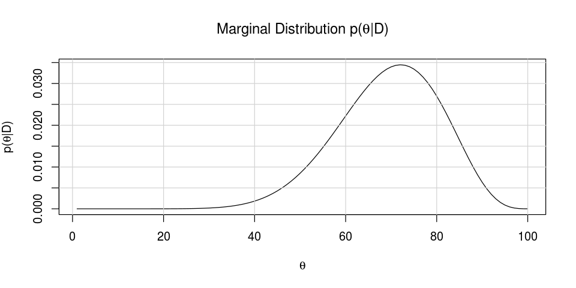

```r
options(repr.plot.width=8, repr.plot.height=4)
plot(marginal.post.theta, xlab=bquote(theta),
     ylab=bquote(paste("p(",theta,"|D)")),type="l")
title(bquote(paste("Marginal Distribution p(",theta,"|D)")))
abline(v=seq(0,100,20),h=seq(.005,.035,.005),col="lightgray")
```

### Multiple coins from a single mint

![coinflip2](https://www.dropbox.com/s/9z0un0imghkuckb/coinflip2.001.png?dl=1 "Source: Kruschke Doing Bayesian Data Analysis")

### Multiple coins from multiple mints

![coinflip3](https://www.dropbox.com/s/dpzak8go5b9c9du/coinflip3.001.png?dl=1 "Source: Kruschke Doing Bayesian Data Analysis")

```r
myData = read.csv("DBDA2E/ch9/data/BattingAverage.csv")
```

```r
head(myData)
```

| Player | PriPos | Hits | AtBats | PlayerNumber | PriPosNumber |
| --- | --- | --- | --- | --- | --- |
| Fernando Abad | Pitcher | 1 | 7 | 1 | 1 |
| Bobby Abreu | Left Field | 53 | 219 | 2 | 7 |
| Tony Abreu | 2nd Base | 18 | 70 | 3 | 4 |
| Dustin Ackley | 2nd Base | 137 | 607 | 4 | 4 |
| Matt Adams | 1st Base | 21 | 86 | 5 | 3 |
| Nathan Adcock | Pitcher | 0 | 1 | 6 | 1 |

```r
baseball_data <- list(
 P = nsamp,
    positions = myData["PriPosNumber"][,1],
    start =  as.numeric(start),
    length =  as.numeric(table(myData["PriPosNumber"][,1])),
    N_positions = as.numeric(length(table(myData["PriPosNumber"][,1]))),
    N =  myData["AtBats"][,1],
    y = myData["Hits"][,1],
    S = 0.01,
    R = 0.01,
    A = 1,
    B = 1
)
```

```r
library(rstan)
fit2 <- stan(
  file = "DBDA2E/ch9/baseball.stan",  # Stan program
  data = baseball_data,    # named list of data
  chains = 4,             # number of Markov chains
  warmup = 1000,          # number of warmup iterations per chain
  iter = 2000,            # total number of iterations per chain
  cores = 2,              # number of cores (using 2 just for the vignette)
  refresh = 1000          # show progress every 'refresh' iterations
  )
```

### Data block

```
data {
    int P;                                // number of players
    int N_positions;                      // number of positions
    int positions[P];  // position for player

    int start[N_positions+1];  // start index for each group of players
    int N[P];                             // number of attemps per player
    int y[P];                             // number of hits per player

    real A;
    real B;
    real S;
    real R;
}
```

### Parameter block

```
parameters {
    real omega0;
    vector[N_positions] omega;  // group level hit rate
    real kappaMinusTwo0;
    vector[N_positions] kappaMinusTwo;
    real theta[P];            // player level hit rate
}
```

### Transformed parameters block

```
transformed parameters {
    real kappa0;
    real alpha0;
    real beta0;
    vector[N_positions] kappa;
    vector[N_positions] alpha;
    vector[N_positions] beta;

    kappa0 = kappaMinusTwo0 + 2;
    alpha0 = omega0 * (kappaMinusTwo0) + 1;
    beta0 = (1 - omega0) * (kappaMinusTwo0) + 1;

    kappa = kappaMinusTwo + 2;
    alpha = omega .* (kappaMinusTwo) + 1;
    beta = (1 - omega) .* (kappaMinusTwo) + 1;
}
```

### Model block

```
model {
    omega0 ~ beta(A, B);
    kappaMinusTwo0 ~ gamma(S, R);

    omega ~ beta(alpha0, beta0);
    kappaMinusTwo ~ gamma(S, R);

    theta ~ beta(alpha[positions], beta[positions]);
    y ~ binomial(N, theta);
}
```

```
ci_level: 0.8 (80% intervals)
outer_level: 0.95 (95% intervals)
```

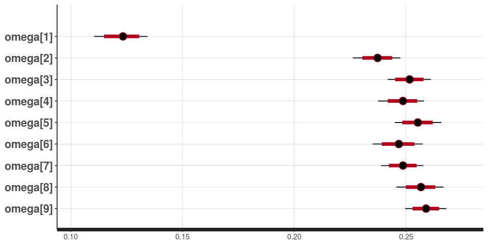

```r
plot(fit2, pars=c("omega"))
```

```
ci_level: 0.8 (80% intervals)
outer_level: 0.95 (95% intervals)
```

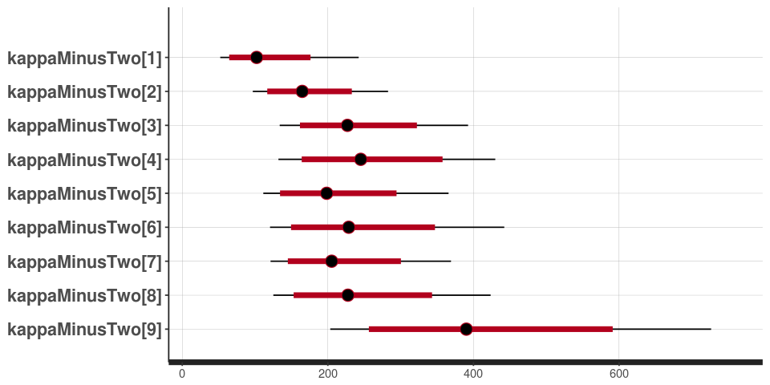

```r
plot(fit2,pars=c("kappaMinusTwo"))
```

## References

1. Kruschke Doing Bayesian Data Analysis 2nd edition